# R Notebook

# Imputação da idade do pai - caso de estudo Paraná

Pacotes e configurações necessárias Há época, foi preciso instalar a ver 4.2 do Rtools para proceder com a instalacao dos pacotes fora do CRAN: - windows: https://cran.r-project.org/bin/windows/Rtools/rtools42/rtools.html

- origem: (read.dbc)[https://github.com/danicat/read.dbc] (microdatasus)[https://github.com/rfsaldanha/microdatasus]

```r
# devtools::install_github("danicat/read.dbc")
# remotes::install_github("rfsaldanha/microdatasus")
```

Carrega pacotes necessários:

```r
library(microdatasus)
library(dplyr)
require(tidyverse)
library(ggplot2)
library(mice)
library(stringr)
library(ggmice)
library(lubridate)
library(readxl)
library(hms)
library(naniar)
library(future.apply)
library(data.table)
library(boot)
library(logger)
library(future)
library(writexl)

options(scipen = 999,
        OutDec = ",")
```

## Buscando dados:

conseguindo os dados e salvando o df: - Extração Faz requisição ao ftp datasus das variáveis selecionadas

```r
#UFs = c("AC", "AL", "AP", "AM", "BA", "CE", "DF", "ES", "GO", "MA", "MT", "MS", "MG", "PA", "PB", "PR", "PE", "PI", "RJ", "RN", "RS", "RO", "RR", "SC", "SP", "SE", "TO")

UFs = c("PR")

for (UF in UFs) {
  nome <- UF
  assign(nome, fetch_datasus(year_start = 2022, year_end = 2022, uf = UF,
                             information_system = "SINASC",
                             vars = c("IDADEMAE", "IDADEPAI", "ESCMAE2010", "ESTCIVMAE","DTDECLARAC", "DTNASC", "HORANASC", "CODESTAB",
                                      "TPFUNCRESP", "RACACORMAE"
                                      )))
  #save(list = nome, file = paste0(UF, ".Rdata"))
  #rm(list = nome)
}

sum(is.na(PR$IDADEPAI))
```

```
## [1] 45948
```

**NAs na idade do pai do PR em 2022 antes de ser processado: 45.948**

Faz processamento dos dados:

A função processa variáveis do SINASC retornadas pela função , atribuindo legendas para variáveis categóricas, incluindo valores NA. Fontes: [process_sinasc.R](https://github.com/rfsaldanha/microdatasus/blob/master/man/process_sinasc.Rd) e process_sinasc.R Altera a idade do pai desta forma:

```r
  # IDADEPAI
  if("IDADEPAI" %in% variables_names){
    data <- data %>%
      dplyr::mutate(IDADEPAI = dplyr::case_match(
        .data$IDADEPAI,
        "0" ~ NA,
        "99" ~ NA,
        .default = .data$IDADEPAI
      )) %>%
      dplyr::mutate(IDADEPAI = as.numeric(.data$IDADEPAI))
  }
```

Itera sobre cada estado para processar dados

```r
for (uf in UFs) {

  dados_processados <- process_sinasc(get(uf), municipality_data = TRUE)
  assign(uf, dados_processados)

}

sum(is.na(PR$IDADEPAI))
```

```
## [1] 46003
```

**NAs na idade do pai do PR em 2022 depois de ser processado: 46.003**

Avaliando a documentação. Esse trecho visualiza a sessão da DN onde estão presentes as categorias associadas ao preenchimento da DN:

```r
library(here)

# Obter o caminho para o diretório raiz do projeto
root_path <- here()

# Exemplo de usar o diretório raiz para acessar um arquivo ou pasta
file_path <- here("manuais/Estrutura_SINASC_para_CD.xlsx")
print(file_path)


Estrutura_SINASC <- read_xlsx(file_path)
#View(Estrutura_SINASC_para_CD)
ver = Estrutura_SINASC %>%
  filter(`Sessão da DN`== "VII -\r\nPreenchimento") %>%
  print()
```

```r
ver = Estrutura_SINASC %>%
  filter(`Nome do campo no DBF`== "DTDECLARAC") %>%
  print()
```

## Preparando dados:

Cortando para o intervalo de referência do período repodrodutivo

```r
for (uf in UFs) {
  temp <- get(uf) %>%
    mutate(IDADEMAE = as.numeric(IDADEMAE),
           IDADEPAI = as.numeric(IDADEPAI),
           Ano = year(as.Date(DTNASC)), # Extrai o ano de nascimento
      missing = ifelse(is.na(IDADEPAI), 1, 0)) |>  # Marcado dos valores ausentes para idade do pai
     mutate(
    # Filtra valores inválidos ou transforma em NA
    HORANASC = ifelse(
      grepl("^[0-9]{1,4}$", HORANASC), # Verifica se HORANASC contém apenas números (1-4 dígitos)
      str_pad(HORANASC, width = 4, pad = "0"), # Preenche com zeros à esquerda se necessário
      NA_character_ # Define como NA se for inválido
    )
  ) %>%
  mutate(
    HORANASC = ifelse(
      is.na(HORANASC),
      NA, # Mantém NA para valores inválidos
      parse_hms(paste0(substr(HORANASC, 1, 2), ":", substr(HORANASC, 3, 4), ":00"))
    ),
    HORANASC = hms::hms(HORANASC),
    DTNASC = as.Date(DTNASC, format = "%Y-%m-%d"),
    DTDECLARAC = as.Date(DTDECLARAC , format = "%Y-%m-%d")
    )

assign(uf, temp)

}
```

#—————– # Simulação

Limpar da memória o que puder se excluído:

```r
rm(list = setdiff(ls(), "PR")) # declarar o que quiser manter
gc()


df_select = get(ls())
rm(list = setdiff(ls(), "df_select"))
gc()
```

Dimensões dos dados

```r
dim(df_select)
```

Resumo de variáveis com dados faltantes:

```r
miss_var_summary(df_select)
```

Remove linhas com valores faltantes: Dimensões dos dados após a retirada das linhas

```r
amostracompleta  = na.omit(df_select)
dim(amostracompleta)
rm(df_select)
setDT(amostracompleta)
```

Inicia arquivo para salvar informações do uso de memória:

```r
log_dir <- "logs"
if (!dir.exists(log_dir)) dir.create(log_dir)
log_appender(appender_file(file.path(log_dir, "memory_monitor.log")))


monitor_memory <- function(phase) {
  mem <- pryr::mem_used()
  log_info("{phase} - Memória usada: {format(mem, big.mark='.', decimal.mark=',')} bytes")
  return(mem)
}
```

Reproduz mecanismos de ausência:

```r
# simular_ausencia <- function(dt, proporcao, mecanismo) {
#   n_missing <- floor(proporcao * nrow(dt))
#   dt_simulado <- copy(dt)
#   if (mecanismo == "MCAR") {
#     dt_simulado[sample(.N, n_missing), IDADEPAI := NA]
#   } else if (mecanismo == "MAR") {
#     setorder(dt_simulado, IDADEMAE)# ordena os dados de forma crescente pela idade da mae
#     dt_simulado[1:n_missing, IDADEPAI := NA]#remove os valores da IDADEPAI onde idade da mae são mais baixos (aplica os NA nas primeiras linhas)
#   } else if (mecanismo == "MNAR") {
#     setorder(dt_simulado, IDADEPAI) # ordena os dados de forma crescente
#     dt_simulado[1:n_missing, IDADEPAI := NA] #remove os valores mais baixos de IDADEPAI (aplica os NA nas primeiras linhas)
#   }
#   return(dt_simulado)
# }


# Função para simular os dados ausentes
simular_ausencia <- function(dt, proporcao, mecanismo) {
  dt_simulado <- copy(dt)

  # Define a quantidade de dados ausentes
  n_missing <- floor(proporcao * nrow(dt_simulado))


  if (mecanismo == "MCAR") {
    dt_simulado$IDADEPAI <- ampute(dt_simulado$IDADEPAI, prop = proporcao)$x

  } else if (mecanismo == "MAR") {
  amputed_mar <- ampute(
  dt_simulado,
  prop = proporcao,
  patterns = c(1,0, 1, 1), # Apenas Idade_Pai ficará faltando
  mech = mecanismo,
  weights = c(1, 0, 0, 0),   # Idade_Mae influencia o missing
  type = c("LEFT")
  )


  } else if (mecanismo == "MNAR") {
  amputed_mnar <- ampute(
  dt_simulado,
  prop = proporcao,
  patterns = c(1,0, 1, 1), # Apenas Idade_Pai ficará faltando
  mech = mecanismo,
  weights = c(0, 1, 0, 0), # A própria Idade_Pai influencia o missing
  type = c("LEFT")
)

  }

  return(dt_simulado)
}
```

Define a função para a imputação

```r
imputar_valores <- function(df, metodo) {
  imput <- df
  if (metodo == "media_simples") {
    media <- mean(df$IDADEPAI, na.rm = TRUE)
    imput$IDADEPAI[is.na(imput$IDADEPAI)] <- media
  } else if (metodo == "mediana_simples") {
    mediana <- median(df$IDADEPAI, na.rm = TRUE)
    imput$IDADEPAI[is.na(imput$IDADEPAI)] <- mediana
  } else if (metodo == "mediana_condicional") {
    imput <- imput %>%
      group_by(IDADEMAE) %>%
      mutate(IDADEPAI = ifelse(is.na(IDADEPAI), median(IDADEPAI, na.rm = TRUE), IDADEPAI)) %>%
      ungroup()
  }
  return(imput)
}
```

Função para extrair decis

```r
extrair_decis <- function(x) {
  quantis <- quantile(x, probs = seq(0.1, 0.9, by = 0.1), na.rm = TRUE)
  names(quantis) <- paste0("dec_", seq(10, 90, by = 10))
  return(as.list(quantis))
}
```

Simulações

```r
# Definir o número de simulações
nsim <- 500

# Define as proporções de dados ausentes a serem testadas
proporcoes <- c(0.2, 0.4, 0.6, 0.8)

# Defina os mecanismos de ausência a serem simulados
mecanismos <- c("MCAR", "MAR", "MNAR")

# Defina o seed para garantir que os números aleatórios sejam consistentes
set.seed(123)

# Roda a função com lapply (sem paralelismo)
resultados_todos <- lapply(proporcoes, function(prop) {
  cat("Executando para proporção:", prop, "\n")

  resultados_completos <- lapply(mecanismos, function(mecanismo) {
    cat("Mecanismo:", mecanismo, "\n")

    # Executa para cada simulação
    resultados_simulacao <- lapply(1:nsim, function(i) {
      set.seed(i)

      # Gerar amostra e simular ausência de dados

      amostra <- amostracompleta[sample(nrow(amostracompleta), replace = TRUE), ]
      amostra_miss <- simular_ausencia(amostra, prop, mecanismo)

      # Rodar todos os métodos de imputação
      resultados_metodos <- lapply(c("media", "mediana", "condicional"), function(metodo) {
        imputado <- imputar_valores(amostra_miss, metodo)

        # Calcular as métricas
        #metricas <- calcular_metricas(amostra$IDADEPAI, imputado$IDADEPAI)

        # Extrair quantis (decis)
        decis_orig <- extrair_decis(amostra$IDADEPAI)
        decis_imput <- extrair_decis(imputado$IDADEPAI)

        # Montar os dados finais para essa simulação
        dados <- c(
          proporcao = prop,
          mecanismo = mecanismo,
          repeticao = i,
          metodo = metodo,
          #do.call(c, metricas),
          original_media = mean(amostra$IDADEPAI, na.rm = TRUE),
          original_mediana = median(amostra$IDADEPAI, na.rm = TRUE),
          original_dp = sd(amostra$IDADEPAI, na.rm = TRUE),
          imputado_media = mean(imputado$IDADEPAI, na.rm = TRUE),
          imputado_mediana = median(imputado$IDADEPAI, na.rm = TRUE),
          imputado_dp = sd(imputado$IDADEPAI, na.rm = TRUE),
          unlist(decis_orig),
          unlist(decis_imput)
        )
        return(as.data.frame(as.list(dados), stringsAsFactors = FALSE))
      })

      # Retornar resultados dos métodos de imputação para esta simulação
      return(do.call(rbind, resultados_metodos))
    })

    # Combinar os resultados de todas as simulações para este mecanismo
    return(bind_rows(resultados_simulacao))
  })

  # Combina os resultados de todos os mecanismos para esta proporção
  return(bind_rows(resultados_completos))
}) %>% bind_rows()

# Exibir resultados finais
head(resultados_todos)
```

```r
load("D:/Mirna/ENCE/DISSERTACAO/imputacao_para_idade_do_pai/codigos/Simulacao/aprimorando_experimento/resultados_todos.RData")
head(resultados_todos)
```

|  | proporcao | mecanismo | repeticao | metodo de imputação | Média original | Mediana original | original_dp | Média imputada | Mediana imputada | imputado_dp | dec_10 | dec_20 | dec_30 | dec_40 | dec_50 | dec_60 | dec_70 | dec_80 | dec_90 | dec_10.1 | dec_20.1 | dec_30.1 | dec_40.1 | dec_50.1 | dec_60.1 | dec_70.1 | dec_80.1 | dec_90.1 |
| --- | --- | --- | --- | --- | --- | --- | --- | --- | --- | --- | --- | --- | --- | --- | --- | --- | --- | --- | --- | --- | --- | --- | --- | --- | --- | --- | --- | --- |
| 1 | 0,2 | MCAR | 1 | media simples | 31,3394360086768 | 31 | 7,55300148531267 | 31,3534842733189 | 31,3534842733189 | 6,75662626197697 | 22 | 25 | 27 | 29 | 31 | 33 | 35 | 37 | 41 | 23 | 26 | 28 | 31 | 31,3534842733189 | 31,3534842733189 | 33 | 36 | 40 |
| 2 | 0,2 | MCAR | 1 | mediana simples | 31,3394360086768 | 31 | 7,55300148531267 | 31,2827874186551 | 31 | 6,75810556605263 | 22 | 25 | 27 | 29 | 31 | 33 | 35 | 37 | 41 | 23 | 26 | 28 | 31 | 31 | 31 | 33 | 36 | 40 |
| 3 | 0,2 | MCAR | 1 | mediana condicional | 31,3394360086768 | 31 | 7,55300148531267 | 31,2171800433839 | 31 | 7,20731704621539 | 22 | 25 | 27 | 29 | 31 | 33 | 35 | 37 | 41 | 22 | 25 | 27 | 29 | 31 | 33 | 35 | 37 | 40 |
| 4 | 0,2 | MCAR | 2 | media simples | 31,3233947939262 | 31 | 7,53225678827612 | 31,3125677874187 | 31,3125677874187 | 6,73192773791143 | 22 | 25 | 27 | 29 | 31 | 33 | 35 | 37 | 41 | 23 | 26 | 28 | 31 | 31,3125677874187 | 31,3125677874187 | 33 | 36 | 40 |
| 5 | 0,2 | MCAR | 2 | mediana simples | 31,3233947939262 | 31 | 7,53225678827612 | 31,2500542299349 | 31 | 6,73308866847024 | 22 | 25 | 27 | 29 | 31 | 33 | 35 | 37 | 41 | 23 | 26 | 28 | 31 | 31 | 31 | 33 | 36 | 40 |
| 6 | 0,2 | MCAR | 2 | mediana condicional | 31,3233947939262 | 31 | 7,53225678827612 | 31,1828036876356 | 31 | 7,18835401051441 | 22 | 25 | 27 | 29 | 31 | 33 | 35 | 37 | 41 | 22 | 25 | 27 | 29 | 31 | 33 | 35 | 37 | 40 |

Define a função para calcular as métricas

```r
calcular_metricas <- function(original, imputado) {
  rmse <- sqrt(mean((imputado- original)^2, na.rm = TRUE))
  rb <-  mean(imputado, na.rm = TRUE)- mean(original, na.rm = TRUE)
  pb <- 100 * abs(mean(imputado, na.rm = TRUE) - mean(original, na.rm = TRUE)/ mean(original, na.rm = TRUE))
  return(list(RMSE = rmse, RB = rb, PB = pb))
}
```

Processar os dados e calcular as métricas para cada grupo

```r
metricas_resultado <- resultados_todos %>%
  group_by(proporcao, mecanismo, `metodo de imputação`) %>%
  # Calcular as métricas para os vetores completos de 'Média original' e 'Média imputada' em todas as repetições
  summarise(
    # Convertendo para numérico e mantendo todos os valores
    Media_original = as.numeric(gsub(",", ".", `Média original`)),
    Media_imputada = as.numeric(gsub(",", ".", `Média imputada`)),
    # Calcular as métricas para todas as repetições dentro do cenário
    metricas = list(calcular_metricas(Media_original, Media_imputada)),
    .groups = "drop"  # Para não manter o agrupamento após a agregação
  )  |>
  # Expandir as métricas em colunas individuais
  mutate(
    RMSE = sapply(metricas, function(x) x$RMSE),
    RB = sapply(metricas, function(x) x$RB),
    PB = sapply(metricas, function(x) x$PB)
  )  |>
  select(proporcao, mecanismo, `metodo de imputação`, RMSE, RB, PB) |>
   distinct(proporcao, mecanismo, `metodo de imputação`, RMSE, RB, PB)
# Exibir o resultado final
print(metricas_resultado)
```

```r
write_xlsx(metricas_resultado, "metricas_resultado.xlsx")
write_xlsx(resultados_todos, "resultados_todos.xlsx")
save(resultados_todos, file ="resultados_todos.RData")
```

## ‘desvio padrão estimado’, da estimativa bootstrap

medida de acurácia-> usada para dar um intevalo de confiança para o parâmetro desconehecido segundo: @article{efron1986bootstrap, title={Bootstrap methods for standard errors, confidence intervals, and other measures of statistical accuracy}, author={Efron, Bradley and Tibshirani, Robert}, journal={Statistical science}, pages={54–75}, year={1986}, publisher={JSTOR} }

Essa métrica calcula a raiz quadrada da média dos quadrados das diferenças entre as estimativas da amostra bootstrap e a média das estimativas bootstrap, ou seja calcula o desvio padrão para $𝐵$ amostras, medindo a variabilidade de $\hat{\sigma}$ devido a escolha aleatória de $y$

```r
resultados_todos$`Média imputada` <- gsub(",", ".", resultados_todos$`Média imputada`)
resultados_todos$`Média imputada` = as.numeric(resultados_todos$`Média imputada`)

desvio_padrao_estimado_media = resultados_todos |>
  group_by(proporcao, mecanismo,`metodo de imputação`) |>
   summarise(
    # Calculando a média das estatísticas de bootstrap
media_bootstrap = mean(`Média imputada`, na.rm = TRUE),
# Calculando o desvio padrão das estatísticas de bootstrap (de acordo com a fórmula bootstrap)
desvio_padrao_media_bootstrap = sqrt(sum((`Média imputada` - media_bootstrap)^2, na.rm = TRUE) / (n() - 1)),
  .groups = "drop"
  )


# Exibir os resultados
print(desvio_padrao_estimado_media)
```

```
## # A tibble: 36 × 5
##    proporcao mecanismo `metodo de imputação` media_bootstrap
##    <chr>     <chr>     <chr>                           <dbl>
##  1 0,2       MAR       media simples                    33.1
##  2 0,2       MAR       mediana condicional              32.8
##  3 0,2       MAR       mediana simples                  33.1
##  4 0,2       MCAR      media simples                    31.3
##  5 0,2       MCAR      mediana condicional              31.2
##  6 0,2       MCAR      mediana simples                  31.3
##  7 0,2       MNAR      media simples                    33.7
##  8 0,2       MNAR      mediana condicional              32.6
##  9 0,2       MNAR      mediana simples                  33.6
## 10 0,4       MAR       media simples                    34.8
## # ℹ 26 more rows
## # ℹ 1 more variable: desvio_padrao_media_bootstrap <dbl>
```

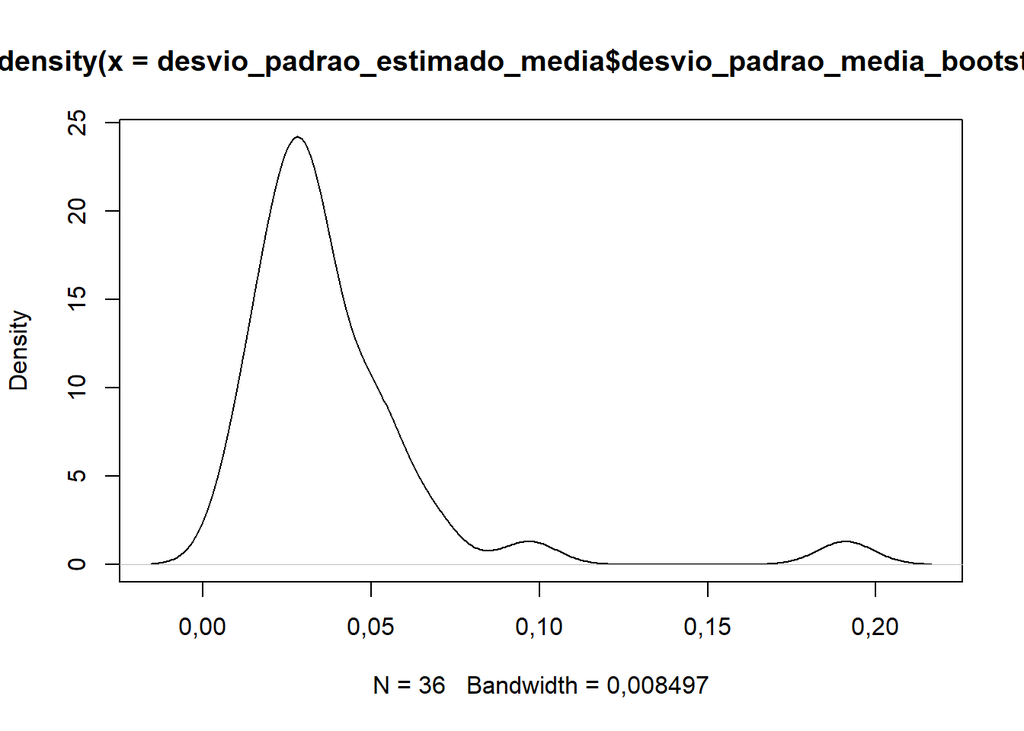

```r
plot(density(desvio_padrao_estimado_media$desvio_padrao_media_bootstrap))
```

## metrica 2 ‘desvio padrão imputado’, da estimativa em relação ao dado completo da amostra $B$

$$REQM_{I} =\sqrt{ \frac{\sum_{b=1}^{B} (\hat{y}^I_{b} -
Y^{obs}_{b})^2}{B-1}}$$
Essa métrica calcula a raiz quadrada da média dos quadrados das diferenças entre a estimativa da amostra bootstrap do dado imputado $\( \hat{y}^I_{b} \)$ e a estimativa do dado observado $Y^{obs}_{b}}$, antes da imputação. Ou seja, calcula a raiz do erro quadrádico médio $𝐵$ amostras, medindo a variabilidade da diferença entre os valores observados e imputados a partir de cada método, devido a seleção aleatória de Y.

```r
resultados_todos$`Média original` <- gsub(",", ".", resultados_todos$`Média original`)
resultados_todos$`Média original` = as.numeric(resultados_todos$`Média original`)

desvio_padrao_estimado_real = resultados_todos |>
  group_by(proporcao, mecanismo,`metodo de imputação`) |>
   summarise(
# Calculando o desvio padrão das estatísticas de bootstrap (de acordo com a fórmula bootstrap)
desvio_padrao_media_real = sqrt(sum((`Média imputada` - `Média original`)^2, na.rm = TRUE) / (n() - 1)),
  .groups = "drop"
  )


# Exibir os resultados
print(desvio_padrao_estimado_real)
```

```
## # A tibble: 36 × 4
##    proporcao mecanismo `metodo de imputação` desvio_padrao_media_real
##    <chr>     <chr>     <chr>                                    <dbl>
##  1 0,2       MAR       media simples                           1.81
##  2 0,2       MAR       mediana condicional                     1.51
##  3 0,2       MAR       mediana simples                         1.77
##  4 0,2       MCAR      media simples                           0.0125
##  5 0,2       MCAR      mediana condicional                     0.126
##  6 0,2       MCAR      mediana simples                         0.0661
##  7 0,2       MNAR      media simples                           2.41
##  8 0,2       MNAR      mediana condicional                     1.32
##  9 0,2       MNAR      mediana simples                         2.26
## 10 0,4       MAR       media simples                           3.44
## # ℹ 26 more rows
```

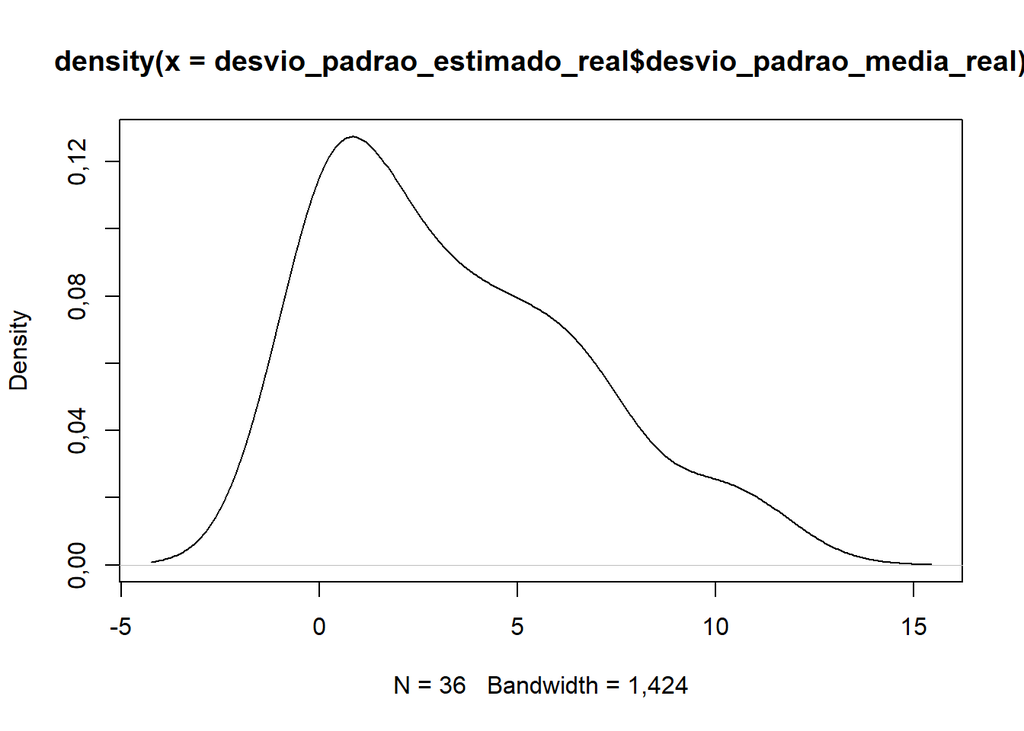

```r
plot(density(desvio_padrao_estimado_real$desvio_padrao_media_real))
```

## metrica 3 ‘desvio padrão original’, da estimativa em relação ao dado completo da amostra original

$$REQM_{dc} =\sqrt{ \frac{\sum_{b=1}^{B} (\hat{y}^I_{b} -
Y_{dc})^2}{B-1}}$$

Essa métrica calcula a raiz quadrada da média dos quadrados das diferenças entre a estimativa da amostra bootstrap do dado imputado $\( \hat{y}^I_{b} \)$ e o parâmetro original, a população com dados completos (observados antes da simulação) $Y_{dc}}$. Ou seja, calcula a raiz do erro quadrádico médio $𝐵$ amostras, medindo a variabilidade da diferença entre o parâmetro e as estimativas dos dados imputados das amostras com simulação de dados faltantes, medindo a variabilidade da estimativa a partir de cada método de imputação e cenário.

```r
desvio_padrao_estimado_dado_completo = resultados_todos |>
  group_by(proporcao, mecanismo,`metodo de imputação`) |>
   summarise(
# Calculando o desvio padrão das estatísticas de bootstrap (de acordo com a fórmula bootstrap)
desvio_padrao_dado_completo = sqrt(sum((`Média imputada` - media_dc_original)^2, na.rm = TRUE) / (n() - 1)),
  .groups = "drop"
  )


# Exibir os resultados
print(desvio_padrao_estimado_real)
```

[output not shown]

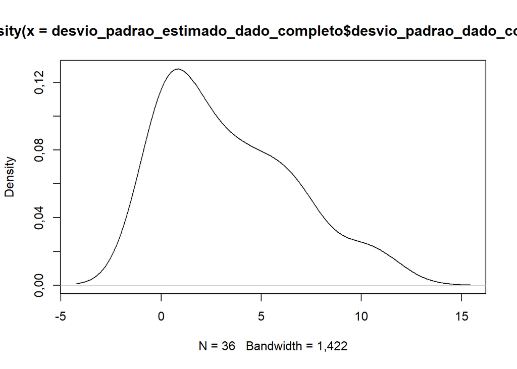

```r
plot(density(desvio_padrao_estimado_dado_completo$desvio_padrao_dado_completo))
```

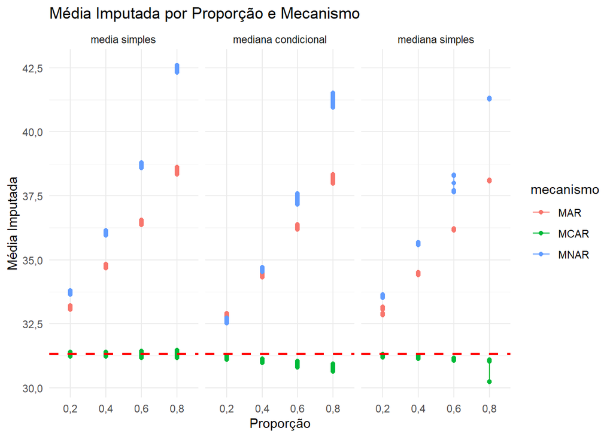

```r
# Supondo que você tenha um dataframe 'resultados_todos'
library(dplyr)
library(ggplot2)

# Agrupar os dados e calcular a média por grupo
teste <- resultados_todos %>%
  group_by(proporcao, mecanismo, `metodo de imputação`)

# Plotar o gráfico com ggplot2
ggplot(teste, aes(x = proporcao, y =`Média imputada`, color = mecanismo)) +
  geom_line() +
  geom_point() +
  facet_wrap(~`metodo de imputação`) + # Para separar os gráficos por 'metodo de imputação'
  geom_hline(yintercept = media_dc_original, linetype = "dashed", color = "red", size = 1) +
  labs(title = "Média Imputada por Proporção e Mecanismo",
       x = "Proporção",
       y = "Média Imputada") +
  theme_minimal()
```

```r
# # Agrupar os dados e calcular a média por grupo
# cenarios <- resultados_todos %>%
#   group_by(proporcao, mecanismo, `metodo de imputação`) |>
# group_split()
#
# library(dplyr)
# library(purrr)
#
# # Supondo que 'cenarios_divididos' seja uma lista de tibbles, cada um representando um cenário
# densidades <- map(cenarios, ~{
#   d <- density(.x$`Média imputada`)
#   tibble(x = d$x, y = d$y)
# }) %>%
#   bind_rows(.id = "cenario")
#
#
# ggplot(densidades, aes(x = x, y = y, group = cenario)) +
#   geom_line(alpha = 0.2) +  # Linhas com 20% de opacidade
#   theme_minimal() +
#   labs(title = "Densidades empíricas das 500 simulações",
#        x = "Valor",
#        y = "Densidade")
```

```r
# library(dplyr)
# library(purrr)
# library(ggplot2)
#
# # Supondo que 'cenarios' seja uma lista de tibbles, cada um representando um cenário
# densidades <- map(cenarios, ~{
#   dens <- density(.x$`Média imputada`)
#   tibble(x = dens$x, y = dens$y, cenario = .x$`metodo de imputação`[1])
# }) %>%
#   bind_rows()
#
# # Atribuir cores específicas para 'MAR' e 'NMAR'
# densidades <- densidades %>%
#   mutate(cor_mecanismo = case_when(
#     cenario == "MAR" ~ "blue",
#     cenario == "NMAR" ~ "orange",
#     TRUE ~ "gray"
#   ))
#
# # Plotar o gráfico com ggplot2
# ggplot(densidades, aes(x = x, y = y, group = cenario, color = cor_mecanismo)) +
#   geom_line(alpha = 0.6) +  # Linhas com 60% de opacidade
#   facet_wrap(~ cenario, scales = "free_y") +  # Um painel para cada cenário
#   scale_color_identity() +  # Usar as cores definidas diretamente
#   theme_minimal() +
#   labs(title = "Densidades Empíricas por Cenário e Mecanismo",
#        x = "Valor",
#        y = "Densidade") +
#   theme(legend.position = "top")
```